# Personality Analyses Final

# Preparing libraries and clearing world environment

```r
rm(list = ls())

library(tidyverse)
```

# Loading ethogram

```r
# loading required files
personality_focal <- read.csv("~/Savolainen Lab/SSB/Data/Personality/Updated_Chloe/clean_focal_follow_data.csv")

ethogram <- tribble(
  ~action,                  ~Category,

  # Assertive
  "(give) Aggression",        "Assertive",
  "Display",                  "Assertive",
  "Open-mouth threat",        "Assertive",
  "Supplant",                 "Assertive",

  # Submissive
  "(receive) Aggression",     "Submissive",
  "Cower",                    "Submissive",
  "Lip smack",                "Submissive",
  "Make room",                "Submissive",
  "Silent bared-teeth face",  "Submissive",

  # Affiliative
  "Brow flash",               "Affiliative",
  "Cooperative infant care",  "Affiliative",
  "(give) Food share",        "Affiliative",
  "(receive) Food share",     "Affiliative",
  "(give) Groom",             "Affiliative",
  "(receive) Groom",          "Affiliative",
  "Hold others",              "Affiliative",
  "Initiate contact",         "Affiliative",
  "Muzzle contact",           "Affiliative",
  "Play",                     "Affiliative",
  "Teeth chatter",            "Affiliative",

  # Sexual
  "(give) Genital stimulation","Sexual",
  "(receive) Genital stimulation","Sexual",
  "(give) Mount",             "Sexual",
  "(receive) Mount",          "Sexual",

  # Exploratory
  "Forage",                   "Exploratory",
  "Object interaction",       "Exploratory",
  "Other species interaction","Exploratory",

  # Neutral
  "Feed",                     "Neutral",
  "Rest",                     "Neutral",

  # Locomotion
  "Locomotion",               "Locomotion",

  # Approach/Avoidance
  "Approach",                 "Approach",
  "Avoid",                    "Avoidance",
  "Reject",                   "Avoidance",

  # Passive contact
  "Passive body contact",     "Passive contact",
  "Stationary in proximity",  "Passive contact",

  # Alone
  "Stationary alone",         "Alone duration",

  # Vigilance
  "Stare",                    "Vigilance",
  "Vigilant scan",            "Vigilance",

  # Self-directed behaviour
  "Masturbate",               "Self-directed behaviour",
  "Self-groom",               "Self-directed behaviour",

  # Vocalisation
  "Vocalisation",             "Vocalisation",

  # Out of sight
  "Out of sight",             "Out of sight"
)

# Check for any behaviours in the data not covered by the ethogram
unmapped <- personality_focal %>%
  anti_join(ethogram, by = "action") %>%
  distinct(action)

if (nrow(unmapped) > 0) {
  message("Unmapped behaviours: ", paste(unmapped$action, collapse = ", "))
} else {
  message("All behaviours successfully mapped.") }
```

# Analysing behavioural repeatability

## Checking number of years each monkey appears in

All monkeys only appear once across dataset

```r
# checking the number of years each monkey appears in
personality_focal_mon <- personality_focal %>%
  group_by(actor_id) %>%
  summarise(
    n_years = n_distinct(year),
    years = paste(sort(unique(year)), collapse = ",")
  ) %>%
  arrange(desc(n_years))
personality_focal_mon
```

| actor_id | n_years | years |
| --- | --- | --- |
| 04T | 1 | 2026 |
| 04Z | 1 | 2026 |
| 0H3 | 1 | 2023 |
| 0H8 | 1 | 2026 |
| 0R1 | 1 | 2026 |
| 0R3 | 1 | 2023 |
| 0U2 | 1 | 2026 |
| 1F2 | 1 | 2026 |
| 1G9 | 1 | 2026 |
| 1J3 | 1 | 2026 |

[output cut: 61 more lines]

## Filtering behaviour

We need to filter rare behaviour as they are not biologically significant and meaningful for our analysis; and they will skew the PCA. This is due to low variance, and introduction of instability into analyses (too many zeros)

### Removing behaviours not pre-defined in ethogram

These behaviours are not biologically significant

```r
removed_behaviours <- personality_focal %>%
  anti_join(ethogram, by = "action") %>%
  distinct(action)

removed_behaviours
```

| action |
| --- |
| Idiosyncratic behaviour |
| Erection |
| Cough |
| Yawn |
| Stare (receive) |
| Brow flash (receive) |

```r
personality_focal_filtered <- personality_focal %>%
  semi_join(ethogram, by = "action")
```

### Recreating proportions

```r
personality_prop_by_focal <- personality_focal_filtered %>%
  group_by(actor_id, focal_number, action) %>%
  summarise(
    action_duration = sum(action_duration, na.rm = TRUE),
    total_duration = first(total_duration),
    .groups = "drop"
  ) %>%
  mutate(
    action_proportion = action_duration / total_duration
  )
```

### Checking rare behaviour

First, checking number of counts per behaviour

```r
behaviour_counts <- personality_prop_by_focal %>%
  group_by(action) %>%
  summarise(
    n_obs = n(),
    n_monkeys = n_distinct(actor_id),
    .groups = "drop"
  ) %>%
  arrange(n_obs)

behaviour_counts
```

| action | n_obs | n_monkeys |
| --- | --- | --- |
| (receive) Genital stimulation | 1 | 1 |
| Cooperative infant care | 1 | 1 |
| Teeth chatter | 2 | 2 |
| (receive) Food share | 3 | 3 |
| (give) Food share | 8 | 7 |
| Initiate contact | 8 | 6 |
| Lip smack | 8 | 8 |
| Other species interaction | 8 | 8 |
| (receive) Mount | 10 | 8 |
| Muzzle contact | 11 | 10 |

[output cut: 31 more lines]

### Removing rare behaviours

```r
keep_behaviours <- behaviour_counts %>%
  filter(
    n_obs >= 5,
    action != "Out of sight" # also removing out of sight
  ) %>%
  pull(action)

personality_repeatability <-
  personality_prop_by_focal %>%
  filter(action %in% keep_behaviours)

removed_stat <- behaviour_counts %>%
  filter(!(action %in% keep_behaviours)) %>%
  arrange(n_obs)
removed_stat
```

| action | n_obs | n_monkeys |
| --- | --- | --- |
| (receive) Genital stimulation | 1 | 1 |
| Cooperative infant care | 1 | 1 |
| Teeth chatter | 2 | 2 |
| (receive) Food share | 3 | 3 |
| Out of sight | 41 | 26 |

```r
NA
```

### Creating new object with proportions

# Merging and calculating average proportion of each action per monkey

This personality matrix excludes all rare behaviours, “out of sight” and behaviours not found in the ethogram

```r
# calculating proportions per focal session
personality_prop_by_focal <- personality_repeatability %>%
  group_by(actor_id, focal_number, action) %>%
  summarise(
    action_duration = sum(action_duration, na.rm = TRUE),
    total_duration = first(total_duration), .groups = "drop"
  ) %>%
  mutate(
    action_proportion = action_duration / total_duration
  )

# checking the total proportions per focal session
focal_proportion_summary <- personality_prop_by_focal %>%
  group_by(actor_id, focal_number) %>%
  summarise(
    total_proportion = sum(action_proportion, na.rm = TRUE),
    .groups = "drop"
  )

# number of focal sessions per monkey
n_focals_per_monkey <- personality_prop_by_focal %>%
  distinct(actor_id, focal_number) %>%
  count(actor_id, name = "n_focals")

# mean proportion per monkey per action
personality_summary <- personality_prop_by_focal %>%
  group_by(actor_id, action) %>%
  summarise(
    total_proportion = sum(action_proportion, na.rm = TRUE),
    .groups = "drop"
  ) %>%
  left_join(n_focals_per_monkey, by = "actor_id") %>%
  mutate(
    mean_proportion = total_proportion / n_focals
  )

# checking total proportions per monkey
monkey_proportion_summary <- personality_summary %>%
  group_by(actor_id) %>%
  summarise(
    total_proportion = sum(mean_proportion, na.rm = TRUE),
    .groups = "drop"
  )

# saving file
write.csv(personality_summary, "~/Savolainen Lab/SSB/Data/Personality/new_filtered_personality_summarised.csv")
```

### Checking variance of behaviours

```r
personality_matrix <- personality_summary %>%
  dplyr::select(actor_id, action, mean_proportion) %>%
  pivot_wider(
    names_from = action,
    values_from = mean_proportion,
    values_fill = 0
  ) %>%
  rename(Animal_ID = actor_id)

# checking variance of behaviours
behaviour_variance <- personality_matrix %>%
  summarise(across(everything(), ~ var(.x, na.rm = TRUE))) %>%
  pivot_longer(
    everything(),
    names_to = "Behaviour",
    values_to = "Variance"
  ) %>%
  arrange(Variance)
behaviour_variance
```

| Behaviour | Variance |
| --- | --- |
| Other species interaction | 1.613967e-07 |
| Lip smack | 1.897450e-07 |
| Muzzle contact | 3.717384e-07 |
| Silent bared-teeth face | 5.606710e-07 |
| (receive) Mount | 5.666148e-07 |
| Initiate contact | 1.169885e-06 |
| Cower | 1.186887e-06 |
| Play | 1.235474e-06 |
| Brow flash | 2.609914e-06 |
| (give) Mount | 4.434018e-06 |

[output cut: 27 more lines]

### Creating a new dataframe filling unobserved behaviours as 0.

```r
all_focals <- personality_focal_filtered %>%
  distinct(actor_id, focal_number)

all_combinations <- tidyr::crossing(
  all_focals,
  action = keep_behaviours
)

personality_repeatability <- all_combinations %>%
  left_join(
    personality_prop_by_focal,
    by = c("actor_id", "focal_number", "action")
  ) %>%
  mutate(
    action_proportion = replace_na(action_proportion, 0)
  )
```

### Checking assumptions of normality for each behaviour

#### Checking histograms for each behaviour

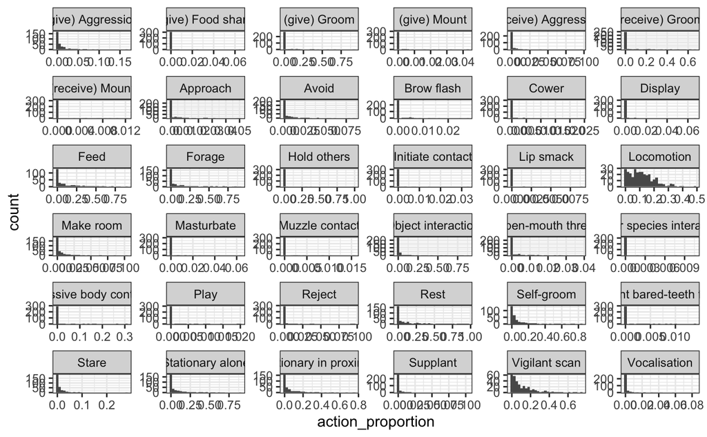

```r
library(ggplot2)

ggplot(
  personality_repeatability,
  aes(x = action_proportion)
) +
  geom_histogram(bins = 30) +
  facet_wrap(~ action, scales = "free") +
  theme_bw()
```